# RMarkdown Lesson Plan

Gus Pendleton

2024-02-06

# Set-up

Make new RMarkdown document. Discuss yaml header, code chunk, and prose

Save RMarkdown document in analysis folder

Confirm everyone is in Source mode

```r
gapminder_df <- read.csv("data/gapminder.csv")

getwd()
```

```
## [1] "/Users/augustuspendleton/Desktop/Schmidt_Lab/Markdown_Lesson"
```

Discuss knitting directory - knitting chunks might have a different working directory than your r session!

Discuss chunk output in console vs. in document - look at yaml header

Assign read.csv to gapminder_df

# Adding new prose with markdown settings

## Headers

### Keep getting smaller

#### As we add hash tags

Point out how we can navigate document

We can make lists with asterisks or hyphens

List 1:

- Item 1
- Item 2
- Item 3

List 2:

- Other Item 1
- Other Item 2

We can make numbered list with numbers:

1. Numbered thing 1
2. Numbered thing 2

And we can make more complex lists:

1. Numbered thing 1
   - Sub list
   - Sub list
2. Numbered thing 2

We can make text **bold** or *italic*

We can incorporate greek symbols like $\mu$ or $\Delta$

We can make [hyperlinks](https://anvilproject.org/guides/content/creating-links)

Knit again

# Let’s insert another R chunk

```r
# Find the median population
median(gapminder_df$pop)
```

```
## [1] 7023596
```

This is okay, but especially if people can’t read understand our code, it’s not that helpful. It would be better if we contextualized these numbers in writing.

# Let’s make a plot

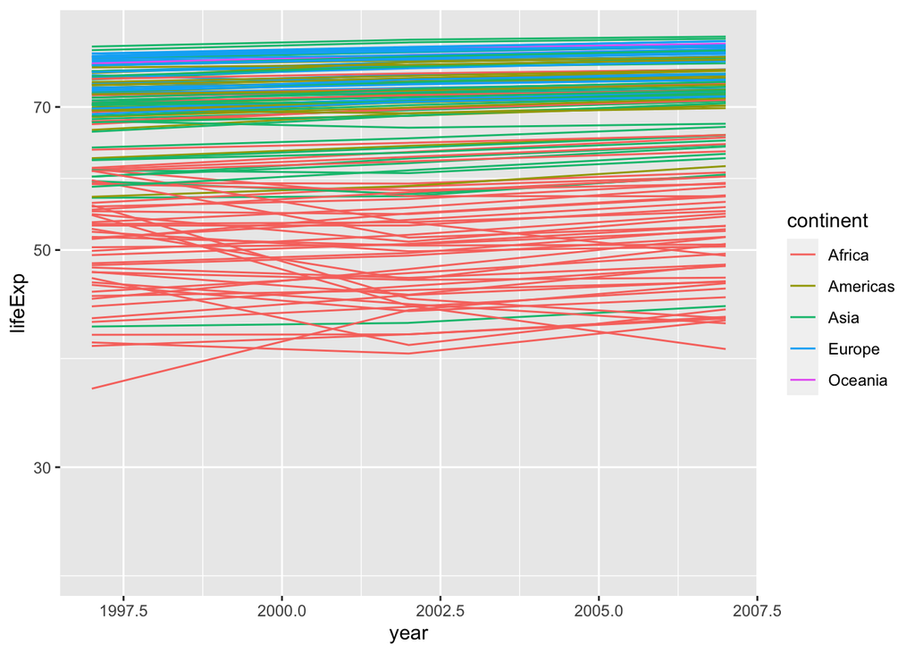

```r
library(ggplot2)

ggplot(gapminder_df, aes(x = year, y = lifeExp, group = country, color = continent)) +
  geom_line() +
  scale_y_log10() +
  scale_x_continuous(limits = c(1997, 2007))
```

```r
  #+ geom_bar()
```

Adding information to code chunks

First add echo = FALSE

Next, add eval = FALSE

Next, add warning = FALSE

Next, simulate what happens when you have an error - can’t knit

Make another type of plot

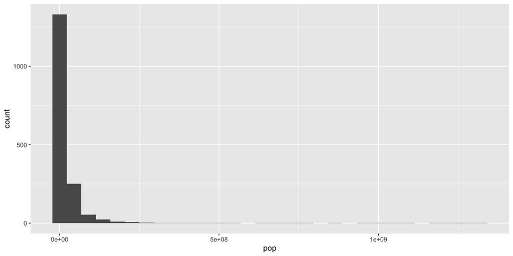

```r
ggplot(gapminder_df, aes(x = pop)) +
  geom_histogram()
```

Next, add message = FALSE

Finally, change figure width

Add some new yaml code code fold table of contents